#### **To: Seattle Airbnb hosts and potential hosts**

#### **From: Siqi Zhang**

#### **Date: 12/12/2019**

#### **RE: Analyzing the Operation Strategies for Seattle Airbnb Hosts and Potential Hosts**

**Introduction**

Are you an Airbnb host? Do you know how to earn more revenue from your Airbnb home? Do you know what is a better way to operate? If you just start thinking to be an Airbnb host, do you know how to set a reasonale price? Do you know whether your location has enough price competitiveness? In this project, I will tell you the answers. I analyzed the Seattle Airbnb data with the sample of 6301 observations. And I mainly focused on whether the host is superhost or not, whether the home is instant bookable, number of customer reviews, performance, neighbourhood group (i.e.: location), price, and annual revenue of Airbnb hosts. I found that:

- Different neighbourhood groups have apparent different home price.
- Customer prefer a relatively low price Airbnb home.
- Being superhost has apparent affect on increasing revenue.
- Instant bookable has apparent affect on increasing revenue.

Also, I will give some recommendations based on my whole analysis to help you operate your Airbnb in a better way. In my analysis, I used the centrality of numeric data (median) to avoid bias which created by extreme values.

**Findings**

Firstly, I found that the Airbnb home price of different neighbourhood group is significantly different. According to the line graph below, we can find that the median price is highest in Downtown, Cascade and Queen Anne, which is $179, $150, $140 separately. And I also found that the prices of high reveiew numbers Airbnb (the red dots) are all lower than $ 250. Meanwhile, most of the data point are clustered under the price of $ 250.

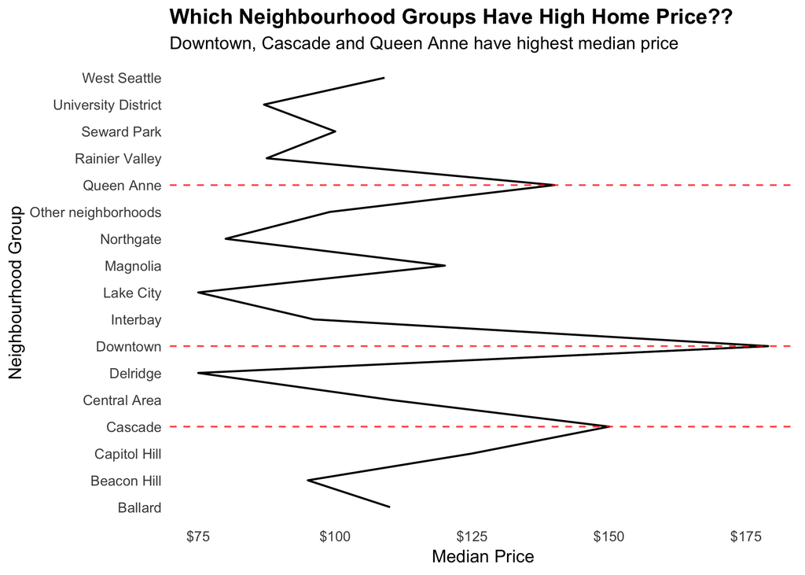

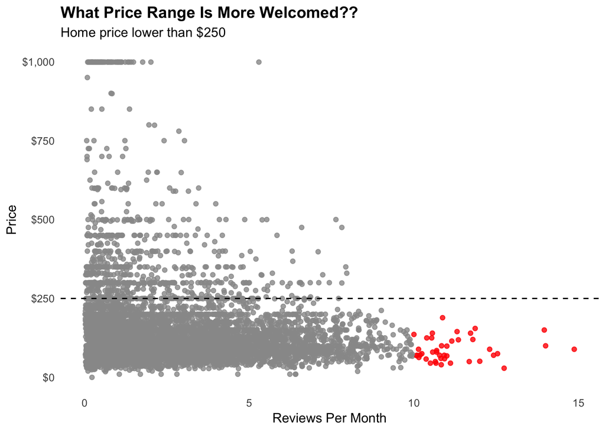

Now, let’s look at the graph of superhost and performance across revenue. Performance here is a ranking based on total review numbers, host years, and review scores, which reflects the overall operation facts. According to the line graph below, we can find that for each performance levels, superhost can earn more revenue than non-superhost. Furthermore, if the superhost has the excellent performance, the revenue will be highest, which is $7457.94. I also found that the revenue of instant bookable Airbnb home can earn more revenue than non-instant bookable Airbnb across all neighbourhood groups (see below the rightside graph). And the median revenues of high revenue range all come from instant bookable group. We can confirm that instant bookable Airbnb can create more revenue for hosts.

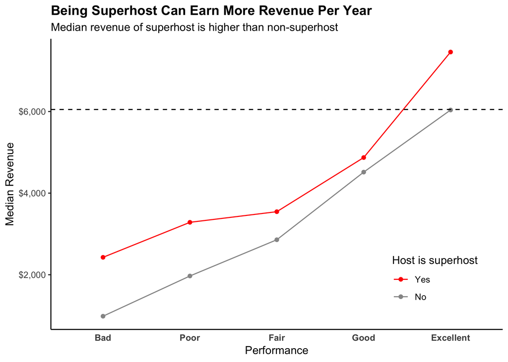

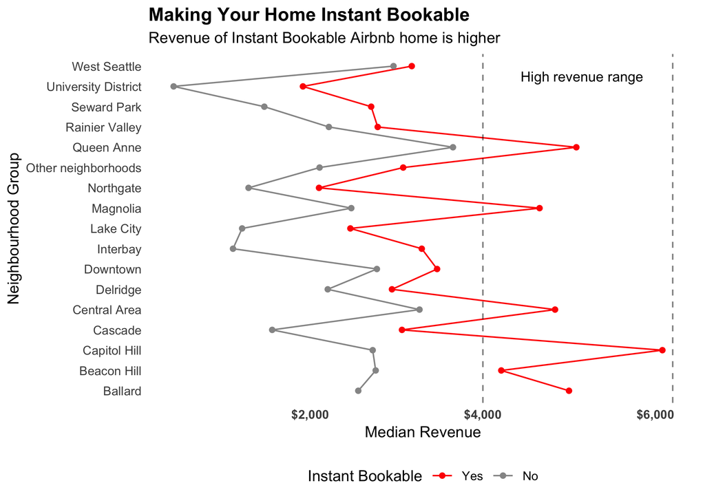

**Conclusion and Recommendations**

Please do not hesitate to contact me if you have questions or would like to discuss the analysis further, it is best to reach me at zhangsiqi@seattleu.edu. I can also provide the Technical Appendix with my complete analysis and the data if you would like more detail.

Best regards,

Siqi Zhang